# Bootstrap Test-Set Prediction Results

## Overview

Every model is fit **once** on the same session-level stratified train set (seed=0, test_size=0.2). The test set is then resampled with replacement $B = 1{,}000$ times to form 95% CIs on the held-out metrics.

The results are split into two figures, each keeping its models on an apples-to-apples evaluation scope:

- **Figure A — all rounds (incl. $t=0$, “no-mask”)**: models evaluated on every round including the opening action. These have no subject-level memory at $t=0$: OLS with only $g, \ell, \delta$ and the Transformer trained without round-1 masking.
- **Figure B — rounds $t \ge 1$ only (“mask”)**: models evaluated on rounds with at least one prior joint action. Includes OLS with joint $n$-gram history ($+$ last 1…5), the Transformer trained with round-1 labels masked, and IRL-SG (defaults & MLE) scored on the same t≥1 rounds.

IRL-SG does predict $t=0$ internally (using $\sigma(\alpha + \beta \Delta_{RD} + e_i)$), but its $t=0$ probabilities use an individual-specific experience term $e_i$ that accumulates across supergames — neither the OLS meta-only nor the Transformer have access to this. To keep Fig B comparable we score IRL-SG only on its in-game Markov-1 transitions ($t \ge 1$).

### IRL-SG, briefly

Six-parameter model. *Initial round* ($t=0$): $P(\text{coop}) = \sigma(\alpha + \beta \Delta_{RD} + e_i)$, with $e_i$ an individual experience term that updates from the prior supergame’s initial action and total payoff. *In-game rounds* ($t \ge 1$): three fixed Markov-1 transition probabilities on the previous joint action — $p_{CC}, p_{CD\_DC}, p_{DD}$ — defining a “semi-grim” strategy.

Parameters are either taken from the paper (defaults) or fit via `differential_evolution` MLE on the training set.

## Sequence length distribution

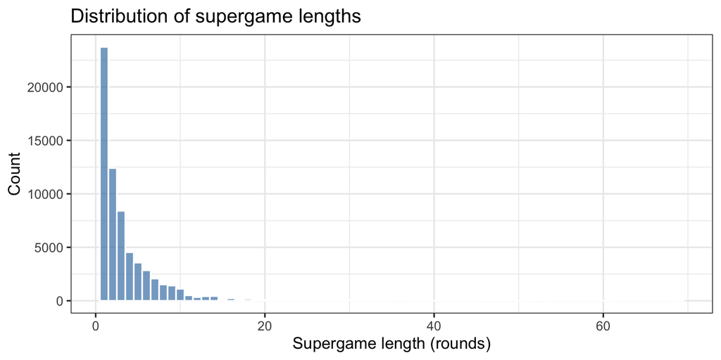

| Stat | Value |
| --- | --- |
| Min | 1 |
| 25th pctl | 1 |
| Median | 2 |
| Mean | 3.6 |
| 75th pctl | 4 |
| 95th pctl | 10 |
| Max | 69 |

## Accuracy and AUC by sequence length

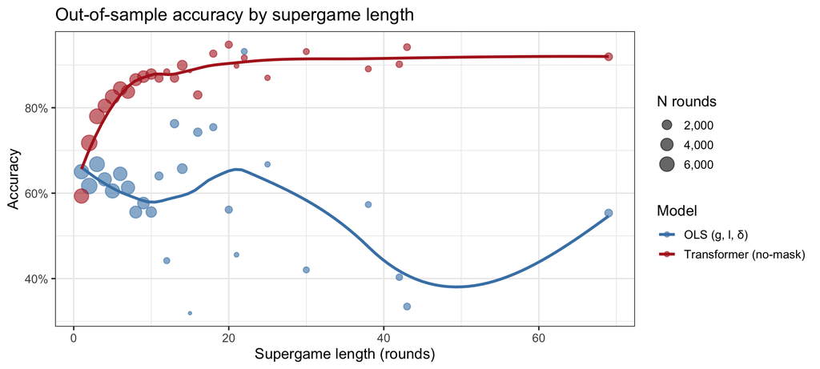

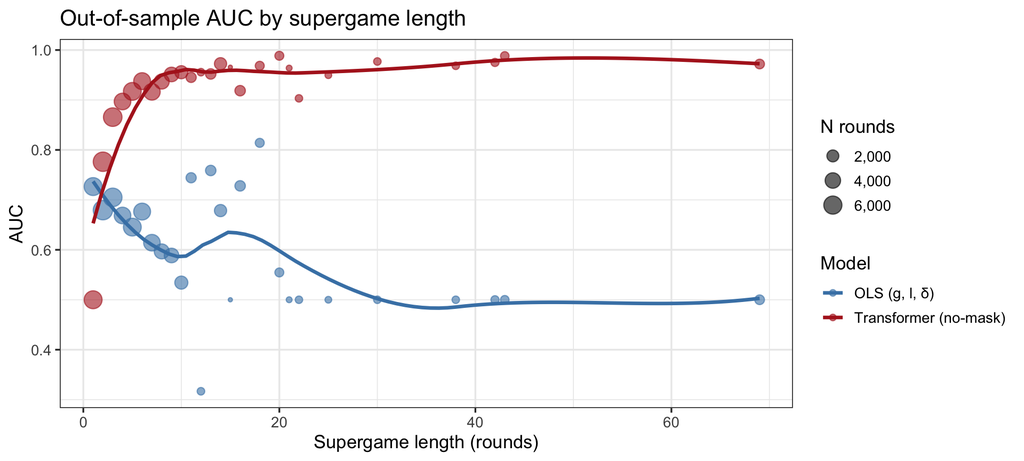

## Figure A — all rounds (incl. $t=0$, “no-mask”)

Models with no subject-level memory that predict every round, including the opening action.

Figure A: test metrics, all rounds (incl. t=0)

| Model | Accuracy | AUC | NLL |
| --- | --- | --- | --- |
| OLS (g, l, δ) | 61.87% [61.50, 62.23] | 0.6453 [0.6411, 0.6496] | 0.6553 [0.6521, 0.6583] |
| Transformer (no-mask) | 81.02% [80.73, 81.32] | 0.9017 [0.8996, 0.9040] | 0.3662 [0.3618, 0.3703] |

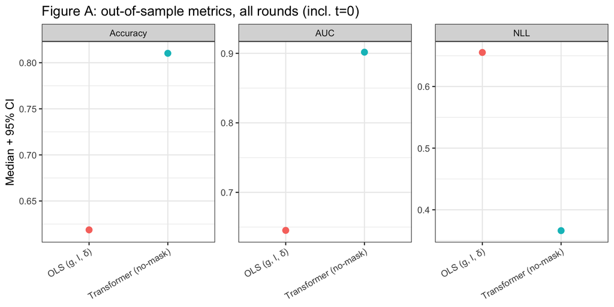

## Figure B — rounds $t \ge 1$ only (“mask”)

OLS with joint $n$-gram history ($+$ last 1…5), Transformer with round-1 labels masked, and IRL-SG (defaults & MLE) scored on the same $t \ge 1$ rounds.

Figure B: test metrics, rounds t >= 1 only

| Model | Accuracy | AUC | NLL |
| --- | --- | --- | --- |
| OLS (+ last 1) | 91.06% [90.80, 91.33] | 0.9445 [0.9422, 0.9469] | 0.2625 [0.2559, 0.2694] |
| OLS (+ last 2) | 92.40% [92.14, 92.69] | 0.9616 [0.9595, 0.9638] | 0.2193 [0.2128, 0.2255] |
| OLS (+ last 3) | 93.10% [92.80, 93.40] | 0.9675 [0.9652, 0.9697] | 0.2004 [0.1936, 0.2075] |
| OLS (+ last 4) | 93.46% [93.16, 93.78] | 0.9717 [0.9694, 0.9739] | 0.1893 [0.1814, 0.1972] |
| OLS (+ last 5) | 93.35% [92.94, 93.72] | 0.9678 [0.9645, 0.9706] | 0.2581 [0.2336, 0.2856] |
| Transformer (mask r1) | 91.42% [91.15, 91.67] | 0.9547 [0.9527, 0.9567] | 0.2433 [0.2379, 0.2487] |
| IRL-SG (defaults) | 91.06% [90.79, 91.31] | 0.9382 [0.9359, 0.9404] | 0.2896 [0.2822, 0.2981] |
| IRL-SG (MLE) | 91.06% [90.79, 91.31] | 0.9382 [0.9359, 0.9404] | 0.2598 [0.2546, 0.2654] |

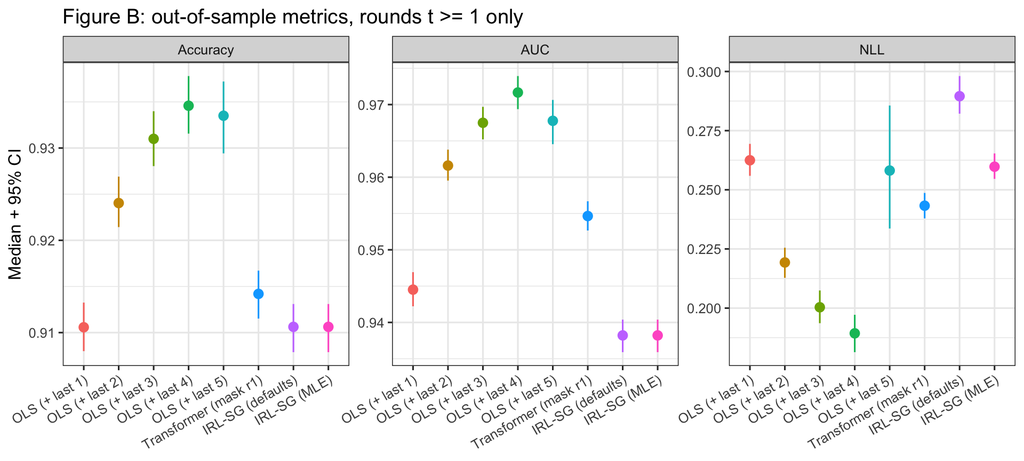

## Pairwise differences: does more history help? (Figure B models)

For each bootstrap iteration we compute the difference in test accuracy between adjacent OLS $n$-gram specs. If the 95% CI excludes zero, the improvement is robust.

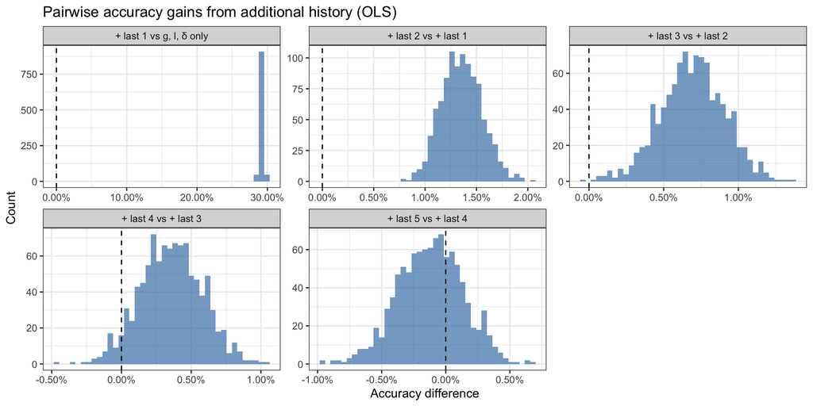

| Comparison | Median diff (CI) | Pr(>0) |
| --- | --- | --- |
| + last 1 vs g, l, δ only | 29.202% [28.743, 29.644] | 100.0% |
| + last 2 vs + last 1 | 1.351% [0.994, 1.753] | 100.0% |
| + last 3 vs + last 2 | 0.695% [0.237, 1.101] | 99.9% |
| + last 4 vs + last 3 | 0.356% [-0.091, 0.802] | 94.8% |
| + last 5 vs + last 4 | -0.110% [-0.644, 0.353] | 32.6% |

## IRL-SG: defaults vs MLE (scoring scopes side by side)

We score the same IRL-SG parameters in two ways: on all rounds (incl. $t=0$, where the $\sigma(\alpha + \beta \Delta_{RD} + e_i)$ initial-round logit + subject experience term contribute) and on $t \ge 1$ only (just the Markov-1 transitions). The gap tells you how much of IRL-SG’s aggregate performance is driven by its initial-round component.

| variant | scope | Accuracy | AUC | NLL |
| --- | --- | --- | --- | --- |
| IRL-SG (MLE) | all rounds (incl. t=0) | 88.13% [87.89, 88.39] | 0.9284 [0.9262, 0.9306] | 0.3130 [0.3081, 0.3177] |
| IRL-SG (MLE) | t ≥ 1 only | 91.06% [90.79, 91.31] | 0.9382 [0.9359, 0.9404] | 0.2598 [0.2546, 0.2654] |
| IRL-SG (defaults) | all rounds (incl. t=0) | 88.30% [88.06, 88.56] | 0.9271 [0.9249, 0.9293] | 0.3449 [0.3370, 0.3521] |
| IRL-SG (defaults) | t ≥ 1 only | 91.06% [90.79, 91.31] | 0.9382 [0.9359, 0.9404] | 0.2896 [0.2822, 0.2981] |

| Metric | MLE - Defaults (95% CI), t >= 1 |
| --- | --- |
| Accuracy | 0.0000 [0.0000, 0.0000] |
| AUC | 0.0000 [0.0000, 0.0000] |
| NLL | -0.0299 [-0.0328, -0.0271] |